# Regression is all you need

# Antes de empezar…

Instala las librerías necesarias (copia y pega en la terminal; no descomentes la línea)…

```r
# install.packages(
#  c("easystats", "GGally", "qqplotr")
# )
```

… y carga las librerías más usadas:

```r
library("easystats")
library("tidyverse")
library("readr")
theme_set(theme_bw())  # cambia el tema de ggplot
```

El modelado estadístico es difícil, por lo que en este notebook solo cubriremos algunos aspectos básicos. Si en el futuro te enfrentas a experimentos complejos, considera buscar ayuda.

> To consult the statistician after an experiment is finished is often merely to ask him to conduct a post mortem examination. He can perhaps say what the experiment died of. (Ronald Fisher)

## Modelado estadístico: las dos culturas

En el artículo clásico Statistical modeling: The two cultures encontramos

> There are two cultures in the use of statistical modeling to reach conclusions from data. One assumes that the data are generated by a given stochastic data model. The other uses algorithmic models and treats the data mechanism as unknown. (Leo Breiman)
- *Explanatory modeling*: modelos estadísticos empleados para probar una teoría. Para ello se emplean variables con un significado científico claro y se evalúa si tienen una relación *significativa* con la variable de interés. $\rightarrow$ “Estadística clásica” basada en **modelos lineales**.
- *Predictive modeling*: modelos cuyo propósito es predecir observaciones nuevas o futuras. La interpretación de los modelos es secundaria. Gran parte del $\rightarrow$ **Aprendizaje automático** (*machine learning*) se basa en esta perspectiva.

## Regresión simple

El modelo básico sobre el que se construye gran parte de la estadística es el modelo de **regresión lineal**:
$$y = a + b\cdot x + \epsilon$$
donde $\epsilon \sim \mathcal{N}(0, \sigma^2)$.

Es instructivo simular datos que sigan este modelo para entender el significado de la ecuación. Para facilitar la interpretación, asumamos que estamos estudiando la altura de los niños (de 0 a 12 años) en función de su edad:

$$altura = a + b\cdot edad + \epsilon
\qquad \qquad \text{(altura en cm y edad en años)}$$

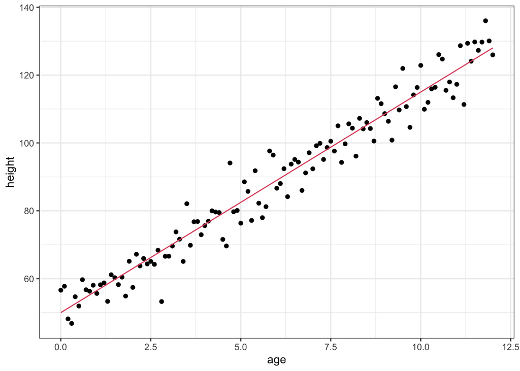

```r
age = seq(0, 12, 0.1)

# No todos los niños de la misma edad miden lo mismo. El término a + b * edad
# debe interpretarse como una altura media...
mean_height = 50 + 6.5 * age
# ... en torno a la cuál habrá fluctuaciones estadísticas que podemos asumir normales.
epsilon = rnorm(length(mean_height), sd = 5)
height = mean_height + epsilon

df = data.frame(
  'age' = age,
  'height' = height,
  'mean_height' = mean_height
)
library("ggplot2")
ggplot(df, aes(x = age, y = height)) +
  geom_point() +
  geom_line(aes(y = mean_height), col = 2)
```

```r
# OR...
# plot(x, y)
# lines(x, expected_behaviour, col = 2)
```

La primera pregunta a la que nos enfrentamos es la siguiente. **Dados los datos $(x, y)$, ¿podemos estimar el `comportamiento medio` (`expected age` en nuestro ejemplo)?**

[figure not shown]

### Ejemplo: linear model (lm)

```r
# 1) crear un modelo lineal... Interpretaremos la fórmula del modelo líneal como
# una forma de preguntar se "la altura depende de la edad".
naive_model = lm(height ~ age, data = df)
# 2) obtener estimaciones de a y b
summary(naive_model)
```

```
##
## Call:
## lm(formula = height ~ age, data = df)
##
## Residuals:
##      Min       1Q   Median       3Q      Max
## -14.6463  -2.6887   0.0939   2.9715  13.7384
##
## Coefficients:
##             Estimate Std. Error t value Pr(>|t|)
## (Intercept)  49.5363     0.8977   55.18   <2e-16 ***
## age           6.5573     0.1293   50.71   <2e-16 ***
## ---
## Signif. codes:  0 '***' 0.001 '**' 0.01 '*' 0.05 '.' 0.1 ' ' 1
##
## Residual standard error: 4.968 on 119 degrees of freedom
## Multiple R-squared:  0.9558, Adjusted R-squared:  0.9554
## F-statistic:  2572 on 1 and 119 DF,  p-value: < 2.2e-16
```

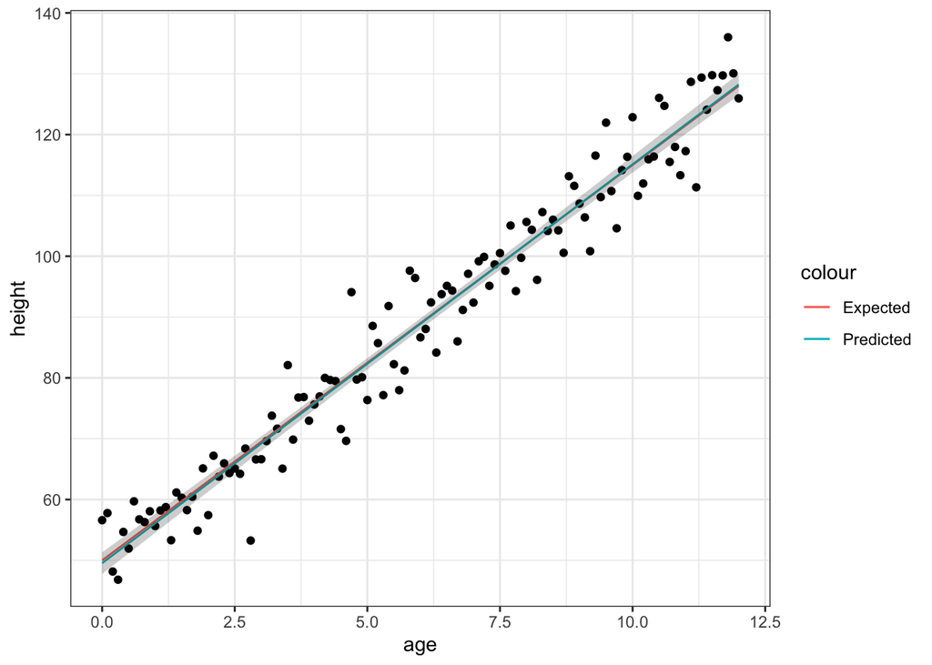

```r
# 3) Obtener predicciones del modelo lineal
preds = predict(naive_model, interval = "confidence")
# 4) visualizar el ajuste
data_and_preds = bind_cols(df, preds)
ggplot(data_and_preds, aes(x = age)) +
  geom_point(aes(y = height)) +
  geom_line(aes(y = mean_height, col = "Expected")) +
  geom_line(aes(y = fit, col = "Predicted")) +
  geom_ribbon(aes(ymin = lwr, ymax = upr), alpha = 0.2, fill = "black")
```

Dado que las estimaciones incorporan el error de estimación, es posible realizar inferencia acerca de la **significación** de los parámetros.

### Ejercicio: ggplot y lm

Si solo nos interesa la visualización y no los valores de los coeficientes podemos emplear `geom_smooth(method = "lm")` para pintar la recta de regresión. Aplícalo a los datos anteriores.

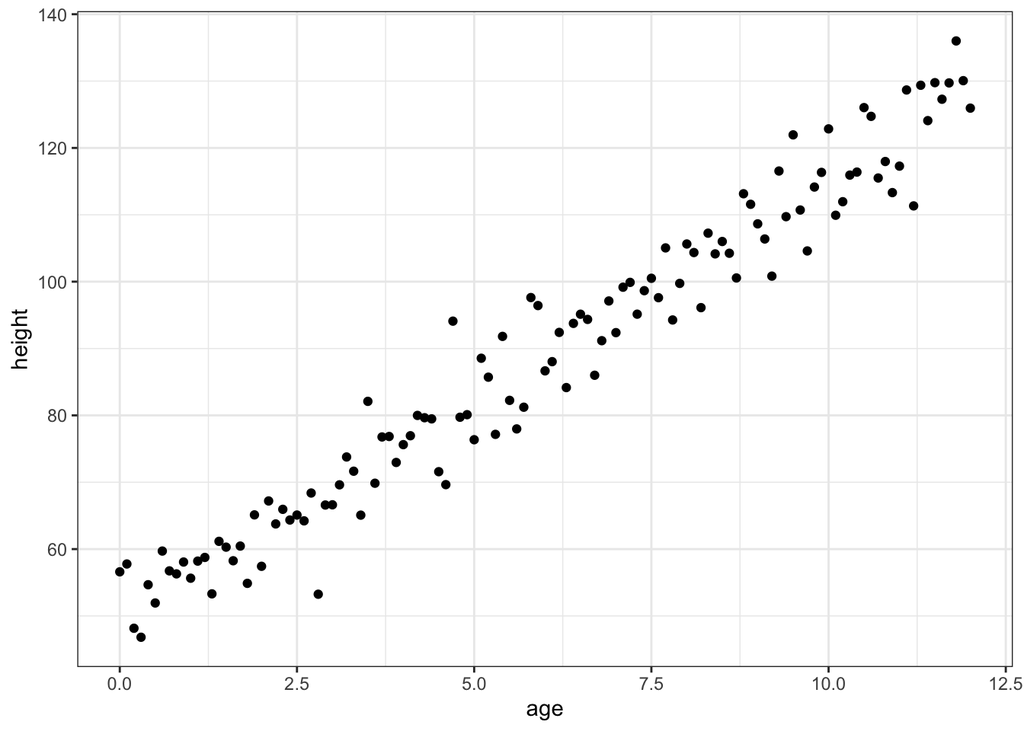

```r
ggplot(df, aes(x = age, y = height)) +
  geom_point() # ???????????? Añade geom_smooth
```

### Ejemplo: inferencia con lm

Un estudiante de biología desea determinar la relación entre temperatura ambiente y frecuencia cardíaca en la rana leopardo, *Rana pipiens*. Para ello, manipula la temperatura en incrementos de 2ºC que van desde 2ºC a 18ºC, registrando la frecuencia cardíaca (pulsaciones por minuto) en cada intervalo. Los datos están disponibles en “hr.csv”.

```r
# 1) leer los datos
# ??
# 2) Crear un modelo lineal
# frog_model = ???
# 3) Inferencia
# ??
```

El diseño experimental y los resultados de la inferencia en el ejemplo de las ranas nos invitan a concluir que “el aumento de la temperatura *causa* un incremento de la frecuencia cardíaca”. Aunque en este caso esto es probablemente correcto, en general, esto no es así. Por muy fuerte que parezca la relación entre las variables $x$ e $y$, **no debemos interpretar una variable como la causa de la otra**. Una relación significativa entre $x$ e $y$ puede ocurrir por varios motivos:

1. $x$ causa $y$.
2. $y$ causa $x$.
3. Existe un tercer factor (llamado **variable de confusión**) que, bien directa o indirectamente, causa $x$ e $y$.

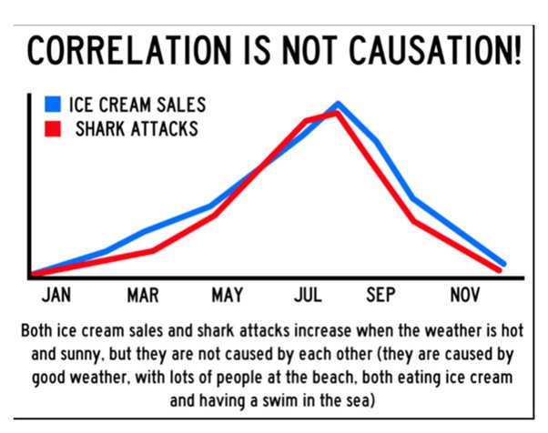

Para poder hacer afirmaciones acerca de la causalidad necesitamos muchos detalles acerca del **diseño experimental**. En general, en nuestros ejercicios no dispondremos de estos datos, por lo que lo mejor es ser cautelosos.

Por otra parte, respecto a los **p-valores**…

> There is some debate among statisticians and researchers about the appropriateness of P values, and that the term “statistical significance” can be misleading. If you have a small P value, it only means that the effect being tested is unlikely to be explained by chance variation alone, in the context of the current study and the current statistical model underlying the test. If you have a large P value, it only means that the observed effect could plausibly be due to chance alone: it is wrong to conclude that there is no effect (emmeans package authors)

En general, hay consenso en que **debe abandonarse la interpretación dicotómica del p-valor** (efecto significativo Vs no-significativo, sobre todo teniendo en cuenta que se basan en un threshold arbitrario) y **que debe favorecerse los resultados basados en intervalos de confianza y tamaños de los efectos** (¡incluso si no son significativos!)

> For example, a study on the effects of two different ambient temperatures on paramecium diameter returning an effect size of 20 µm and a p-value of 0.1, if centred on p-value interpretation would conclude ‘no effect’ of temperature, despite the best supported effect size being 20, not 0. An interpretation based on effect size and confidence intervals could, for example, state: ‘Our results suggest that paramecium kept at the lower temperature will be on average 20 µm larger in size, however a difference in size ranging between −4 and 50 µm is also reasonably likely’. (…), the latter approach acknowledges the uncertainty in the estimated effect size while also ensuring that you do not make a false claim either of no effect if p > 0.05, or an overly confident claim. (Lewis G. Halsey, [The reign of p-value is over](https://royalsocietypublishing.org/doi/10.1098/rsbl.2019.0174))

### Ejemplo: intervalos de confianza en lm

```r
# # summary(frog_model)
# confint(frog_model)
```

### Validación de los modelos

Evidentemente cualquier interpretación está supeditada a que el modelo sea correcto. Debemos ser muy cuidadosos a la hora de verificar que se cumplan las asunciones del modelo de regresión lineal. Podemos usar el acrónimo **LINE** para recordar las asunciones más importantes del modelo: **Linear, Independent, Normal, Equal variances**.

### Ejemplo: evaluación del modelo `naive_model`

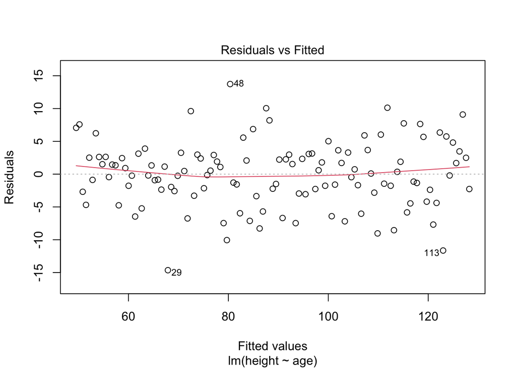

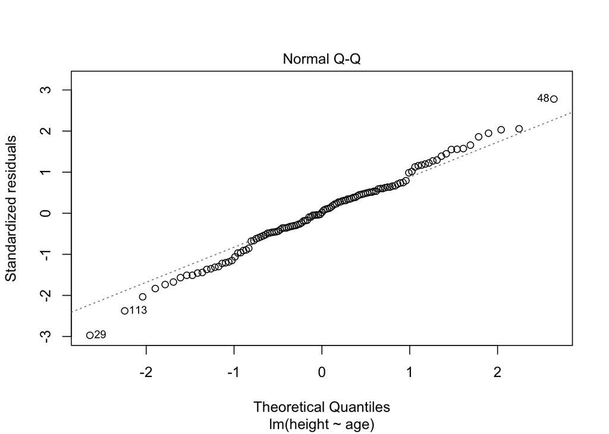

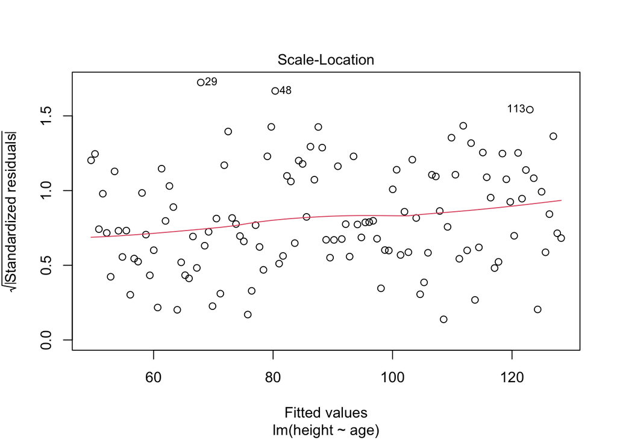

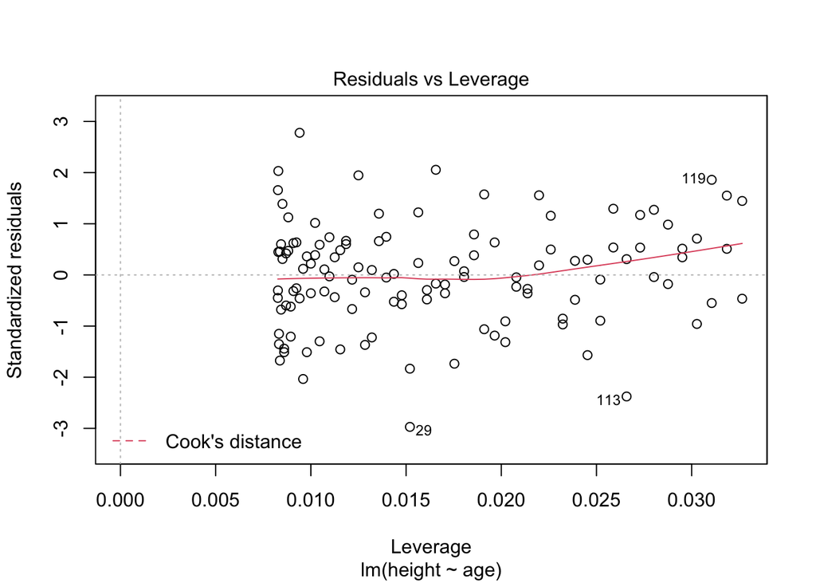

```r
# Lo primero siempre debe ser pintar las predicciones (por ejemplo, con geom_smooth)
# para ver si se ajustan de forma razonable a los datos. Como ya lo hemos hecho,
# lo saltamos...

# Para QQplot también nos apoyaremos en check_normality
plot(naive_model, ask = FALSE)
```

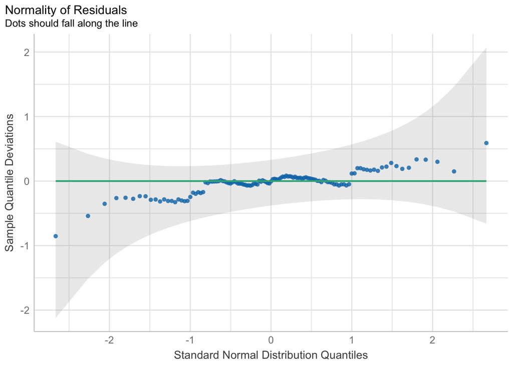

```r
# Comprobar la normalidad con qqplot puede ser difícil. Podemos apoyarnos en
# performance::check_normality (librería easystats)

# check_normality corre shapiro.test, pero tal y como resalta la documentación
# "this formal test almost always yields significant results for the distribution
# of residuals and visual inspection (e.g. Q-Q plots) are preferable."
is_norm = check_normality(naive_model)

# Para hacer la inspección visual
plot(is_norm, type = "qq", detrend = TRUE) # probar con TRUE y FALSE
```

## Transformaciones logarítmicas

### Ejemplo: estudio y rendimiento

Se desea estudiar la relación entre el tiempo de estudio y el rendimiento en un examen particular. Datos en “exam_scores.csv”.

```r
scores = read_csv("data/exam_scores.csv")
```

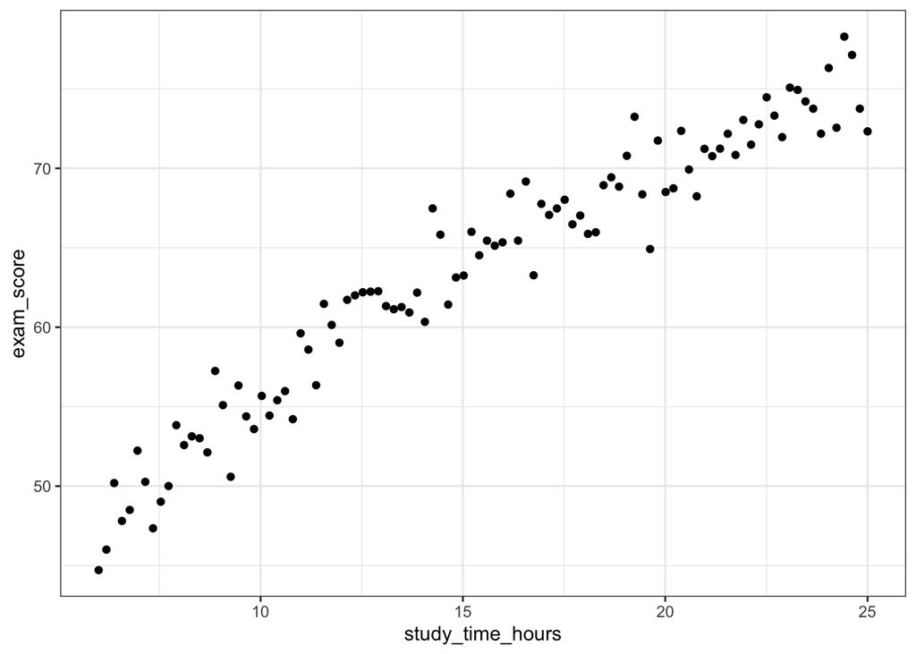

```r
ggplot(scores, aes(x = study_time_hours, y = exam_score)) +
  geom_point()
```

Nótese que un aumento en el tiempo de estudio tiene un impacto sustancial en el rendimiento inicial, pero este impacto disminuye a medida que aumenta el tiempo de estudio. Lo más reseñable para nuestro análisis es que la relación entre ambas variables es ¡NO-LINEAL!

**Las transformaciones de variables nos pueden ayudar en estos casos**. La más típica es la **transformación logarítmica, que ayuda a linearizar relaciones**. Algunos casos habituales donde se suele emplear el logaritmo son:

- Con variables donde se espera un efecto multiplicativo y/o rendimientos crecientes/decrecientes.
- Con variables donde es más relevante el orden de magnitud que el valor numérico preciso.

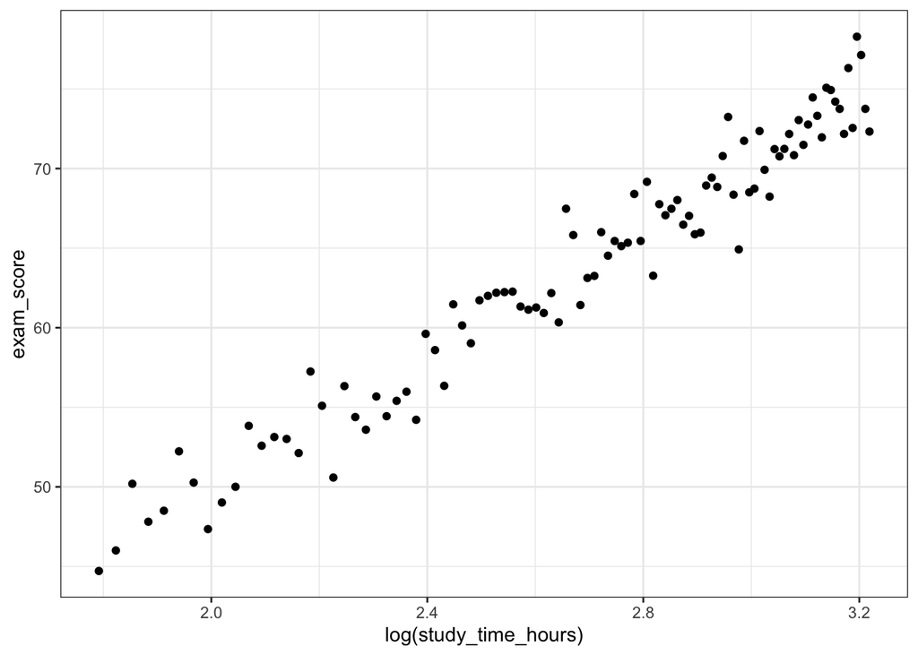

```r
ggplot(scores, aes(x = log(study_time_hours), y = exam_score)) +
  geom_point()
```

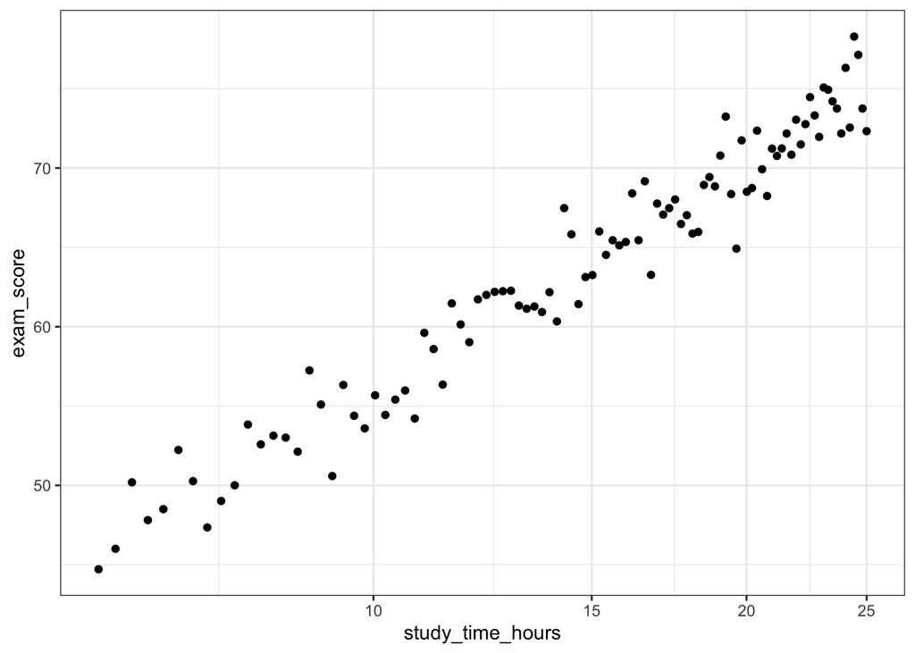

```r
# o mejor...
ggplot(scores, aes(x = study_time_hours, y = exam_score)) +
  geom_point() +
  coord_trans(x = "log")
```

```r
study_model = lm(exam_score ~ log(study_time_hours), scores)
summary(study_model)
```

```
##
## Call:
## lm(formula = exam_score ~ log(study_time_hours), data = scores)
##
## Residuals:
##     Min      1Q  Median      3Q     Max
## -4.8842 -1.1325 -0.0648  1.2576  4.1601
##
## Coefficients:
##                       Estimate Std. Error t value Pr(>|t|)
## (Intercept)             9.4463     1.2444   7.591 1.87e-11 ***
## log(study_time_hours)  20.2753     0.4613  43.948  < 2e-16 ***
## ---
## Signif. codes:  0 '***' 0.001 '**' 0.01 '*' 0.05 '.' 0.1 ' ' 1
##
## Residual standard error: 1.832 on 98 degrees of freedom
## Multiple R-squared:  0.9517, Adjusted R-squared:  0.9512
## F-statistic:  1931 on 1 and 98 DF,  p-value: < 2.2e-16
```

¡Ojo! Con este truco, cambia la interpretación de los coeficientes de la regresión. Usa `log_interpretation` de `utils.R`:

```r
suppressPackageStartupMessages(
  source("utils.R")
)
log_interpretation(20.2753, "predictor", percent_increase = 20)
```

```
## A 20% increase in x => y increases by 3.696624 units
```